# 《客户购买行为预测和分析》

## 一、导包及数据获取

数据来源：https://www.kaggle.com/datasets/gauthamvijayaraj/customer-purchase-behavior-dataset-e-commerce/data

数据量：50w

客户细分和分析（用户画像）

分析人口统计学、行为、消费和价值特征因素对购买的影响

```python
import pandas as pd
import numpy as np
from IPython.display import Image
import matplotlib.pyplot as plt
from sklearn.preprocessing import StandardScaler, OneHotEncoder
from sklearn.compose import ColumnTransformer
import seaborn as sns
from sklearn.cluster import KMeans
```

```python
df = pd.read_csv('D:\\python code\\data\\customerData_500k.csv')
```

## 二、数据清洗

### 查看表头结构

```python
df.head()
```

|  | Age | AnnualIncome | NumberOfPurchases | TimeSpentOnWebsite | CustomerTenureYears | LastPurchaseDaysAgo | Gender | ProductCategory | PreferredDevice | Region | ReferralSource | CustomerSegment | SessionCount | CustomerSatisfaction | PurchaseStatus |
| --- | --- | --- | --- | --- | --- | --- | --- | --- | --- | --- | --- | --- | --- | --- | --- |
| 0 | 37 | 57722.57241 | 19 | 5.908826 | 1.093430 | 11 | Male | Furniture | Desktop | South | Paid Ads | Regular | 3 | 2 | 1 |
| 1 | 63 | 21328.92588 | 10 | 6.970749 | 0.649246 | 20 | Female | Furniture | Mobile | East | Organic | VIP | 2 | 3 | 0 |
| 2 | 60 | 150537.74250 | 19 | 35.004954 | 3.858211 | 25 | Male | Electronics | Desktop | South | Organic | VIP | 5 | 2 | 0 |
| 3 | 19 | 63508.76255 | 10 | 14.818000 | 7.554374 | 20 | Male | Furniture | Desktop | West | Paid Ads | Premium | 1 | 3 | 0 |
| 4 | 54 | 100399.55840 | 19 | 55.925462 | 0.197411 | 92 | Male | Electronics | Mobile | South | Referral | Regular | 1 | 2 | 0 |

### 查看纬度信息

```python
df.info()
```

```
<class 'pandas.core.frame.DataFrame'>
RangeIndex: 500000 entries, 0 to 499999
Data columns (total 15 columns):
 #   Column                Non-Null Count   Dtype
---  ------                --------------   -----
 0   Age                   500000 non-null  int64
 1   AnnualIncome          500000 non-null  float64
 2   NumberOfPurchases     500000 non-null  int64
 3   TimeSpentOnWebsite    500000 non-null  float64
 4   CustomerTenureYears   500000 non-null  float64
 5   LastPurchaseDaysAgo   500000 non-null  int64
 6   Gender                500000 non-null  object
 7   ProductCategory       500000 non-null  object
 8   PreferredDevice       500000 non-null  object
 9   Region                500000 non-null  object
 10  ReferralSource        500000 non-null  object
 11  CustomerSegment       500000 non-null  object
 12  SessionCount          500000 non-null  int64
 13  CustomerSatisfaction  500000 non-null  int64
 14  PurchaseStatus        500000 non-null  int64
dtypes: float64(3), int64(6), object(6)
memory usage: 57.2+ MB
```

### 修改为中文纬度名

```python
column_mapping = {
    'Age': '年龄',
    'AnnualIncome': '年收入',
    'NumberOfPurchases': '购买次数',
    'TimeSpentOnWebsite': '网站停留时间',
    'CustomerTenureYears': '客户年限',
    'LastPurchaseDaysAgo': '上次购买天数',
    'ReferralSource': '推荐来源',
    'Gender': '性别',
    'ProductCategory': '产品类别',
    'PreferredDevice': '偏好设备',
    'Region': '地区',
    'CustomerSegment': '客户细分',
    'DiscountsAvailed': '使用折扣次数',
    'SessionCount': '访问次数',
    'CustomerSatisfaction': '客户满意度',
    'PurchaseStatus': '购买状态'  # 或“是否购买”（1/0可能表示是/否）
}

# 批量修改列名
df = df.rename(columns=column_mapping)

# 查看修改后的列名
print(df.columns)
```

```
Index(['年龄', '年收入', '购买次数', '网站停留时间', '客户年限', '上次购买天数', '性别', '产品类别', '偏好设备',
       '地区', '推荐来源', '客户细分', '访问次数', '客户满意度', '购买状态'],
      dtype='object')
```

### 修正数据类型

```python
##查看类型
df. dtypes
```

```
年龄          int64
年收入       float64
购买次数        int64
网站停留时间    float64
客户年限      float64
上次购买天数      int64
性别         object
产品类别       object
偏好设备       object
地区         object
推荐来源       object
客户细分       object
访问次数        int64
客户满意度       int64
购买状态        int64
dtype: object
```

### 查看统计概要

```python
df.describe()
```

|  | 年龄 | 年收入 | 购买次数 | 网站停留时间 | 客户年限 | 上次购买天数 | 访问次数 | 客户满意度 | 购买状态 |
| --- | --- | --- | --- | --- | --- | --- | --- | --- | --- |
| count | 500000.000000 | 500000.000000 | 500000.000000 | 500000.000000 | 500000.000000 | 500000.000000 | 500000.000000 | 500000.000000 | 500000.000000 |
| mean | 43.941044 | 85071.804966 | 11.387584 | 30.594395 | 2.163483 | 60.191362 | 2.351750 | 3.219764 | 0.418354 |
| std | 15.756232 | 39586.271859 | 6.000702 | 17.585290 | 2.197354 | 54.886826 | 1.485597 | 0.826482 | 0.493289 |
| min | 15.000000 | 11966.385650 | -1.000000 | -3.804161 | -0.418429 | -11.000000 | 1.000000 | 1.000000 | 0.000000 |
| 25% | 30.000000 | 51998.815727 | 6.000000 | 15.843041 | 0.592285 | 16.000000 | 1.000000 | 3.000000 | 0.000000 |
| 50% | 44.000000 | 83748.351845 | 12.000000 | 30.763164 | 1.466097 | 31.000000 | 2.000000 | 3.000000 | 0.000000 |
| 75% | 57.000000 | 116554.694575 | 16.000000 | 45.012866 | 3.009516 | 105.000000 | 3.000000 | 4.000000 | 1.000000 |
| max | 81.000000 | 204178.294400 | 28.000000 | 78.364251 | 15.346356 | 189.000000 | 12.000000 | 5.000000 | 1.000000 |

### 处理重复值

```python
df.duplicated().sum()
```

```
np.int64(0)
```

这表示表中没有重复行

### 处理数值列中小于0的值

```python
df[df[['年龄','年收入','购买次数','网站停留时间','客户年限','上次购买天数','访问次数','客户满意度','购买状态']] < 0]
```

|  | 年龄 | 年收入 | 购买次数 | 网站停留时间 | 客户年限 | 上次购买天数 | 性别 | 产品类别 | 偏好设备 | 地区 | 推荐来源 | 客户细分 | 访问次数 | 客户满意度 | 购买状态 |
| --- | --- | --- | --- | --- | --- | --- | --- | --- | --- | --- | --- | --- | --- | --- | --- |
| 0 | NaN | NaN | NaN | NaN | NaN | NaN | NaN | NaN | NaN | NaN | NaN | NaN | NaN | NaN | NaN |
| 1 | NaN | NaN | NaN | NaN | NaN | NaN | NaN | NaN | NaN | NaN | NaN | NaN | NaN | NaN | NaN |
| 2 | NaN | NaN | NaN | NaN | NaN | NaN | NaN | NaN | NaN | NaN | NaN | NaN | NaN | NaN | NaN |
| 3 | NaN | NaN | NaN | NaN | NaN | NaN | NaN | NaN | NaN | NaN | NaN | NaN | NaN | NaN | NaN |
| 4 | NaN | NaN | NaN | NaN | NaN | NaN | NaN | NaN | NaN | NaN | NaN | NaN | NaN | NaN | NaN |
| ... | ... | ... | ... | ... | ... | ... | ... | ... | ... | ... | ... | ... | ... | ... | ... |
| 499995 | NaN | NaN | NaN | NaN | NaN | NaN | NaN | NaN | NaN | NaN | NaN | NaN | NaN | NaN | NaN |
| 499996 | NaN | NaN | NaN | NaN | -0.006796 | NaN | NaN | NaN | NaN | NaN | NaN | NaN | NaN | NaN | NaN |
| 499997 | NaN | NaN | NaN | NaN | NaN | NaN | NaN | NaN | NaN | NaN | NaN | NaN | NaN | NaN | NaN |
| 499998 | NaN | NaN | NaN | NaN | NaN | NaN | NaN | NaN | NaN | NaN | NaN | NaN | NaN | NaN | NaN |
| 499999 | NaN | NaN | NaN | NaN | NaN | NaN | NaN | NaN | NaN | NaN | NaN | NaN | NaN | NaN | NaN |

500000 rows × 15 columns

```python
cols = ['年龄','年收入','购买次数','网站停留时间','客户年限',
        '上次购买天数','访问次数','客户满意度','购买状态']

# 将小于0的值设为NaN（仅限指定列）
df[cols] = df[cols].mask(df[cols] < 0, np.nan)

# 计算均值并填充
means = df[cols].mean()
df[cols] = df[cols].fillna(means)
df[cols]
```

|  | 年龄 | 年收入 | 购买次数 | 网站停留时间 | 客户年限 | 上次购买天数 | 访问次数 | 客户满意度 | 购买状态 |
| --- | --- | --- | --- | --- | --- | --- | --- | --- | --- |
| 0 | 37 | 57722.57241 | 19.0 | 5.908826 | 1.093430 | 11.0 | 3 | 2 | 1 |
| 1 | 63 | 21328.92588 | 10.0 | 6.970749 | 0.649246 | 20.0 | 2 | 3 | 0 |
| 2 | 60 | 150537.74250 | 19.0 | 35.004954 | 3.858211 | 25.0 | 5 | 2 | 0 |
| 3 | 19 | 63508.76255 | 10.0 | 14.818000 | 7.554374 | 20.0 | 1 | 3 | 0 |
| 4 | 54 | 100399.55840 | 19.0 | 55.925462 | 0.197411 | 92.0 | 1 | 2 | 0 |
| ... | ... | ... | ... | ... | ... | ... | ... | ... | ... |
| 499995 | 56 | 113252.44120 | 16.0 | 26.327274 | 6.003410 | 135.0 | 1 | 2 | 0 |
| 499996 | 40 | 59758.01615 | 13.0 | 7.124139 | 2.214477 | 123.0 | 3 | 3 | 0 |
| 499997 | 50 | 64968.69666 | 10.0 | 28.440505 | 0.649710 | 20.0 | 2 | 2 | 0 |
| 499998 | 38 | 150832.32070 | 8.0 | 50.161579 | 2.903859 | 8.0 | 1 | 3 | 1 |
| 499999 | 75 | 103195.11530 | 4.0 | 23.528559 | 2.804215 | 168.0 | 1 | 4 | 0 |

500000 rows × 9 columns

### 处理缺失值

```python
df.isnull().sum()
```

```
年龄        0
年收入       0
购买次数      0
网站停留时间    0
客户年限      0
上次购买天数    0
性别        0
产品类别      0
偏好设备      0
地区        0
推荐来源      0
客户细分      0
访问次数      0
客户满意度     0
购买状态      0
dtype: int64
```

这表示表中无缺失值

## 三、数据探索性分析

### 1、基本统计分析

```python
##数值型基本统计量
print('数值型特征基本统计量')
df.select_dtypes(include=['int64', 'float64']).describe()
```

```
数值型特征基本统计量
```

|  | 年龄 | 年收入 | 购买次数 | 网站停留时间 | 客户年限 | 上次购买天数 | 访问次数 | 客户满意度 | 购买状态 |
| --- | --- | --- | --- | --- | --- | --- | --- | --- | --- |
| count | 500000.000000 | 500000.000000 | 500000.000000 | 500000.000000 | 5.000000e+05 | 500000.000000 | 500000.000000 | 500000.000000 | 500000.000000 |
| mean | 43.941044 | 85071.804966 | 11.397353 | 31.133300 | 2.214477e+00 | 61.194843 | 2.351750 | 3.219764 | 0.418354 |
| std | 15.756232 | 39586.271859 | 5.990610 | 17.099365 | 2.171226e+00 | 54.312631 | 1.485597 | 0.826482 | 0.493289 |
| min | 15.000000 | 11966.385650 | 0.000000 | 0.000041 | 5.790000e-08 | 0.000000 | 1.000000 | 1.000000 | 0.000000 |
| 25% | 30.000000 | 51998.815727 | 6.000000 | 16.908534 | 6.568507e-01 | 17.000000 | 1.000000 | 3.000000 | 0.000000 |
| 50% | 44.000000 | 83748.351845 | 12.000000 | 31.133300 | 1.565669e+00 | 34.000000 | 2.000000 | 3.000000 | 0.000000 |
| 75% | 57.000000 | 116554.694575 | 16.000000 | 45.012866 | 3.009516e+00 | 105.000000 | 3.000000 | 4.000000 | 1.000000 |
| max | 81.000000 | 204178.294400 | 28.000000 | 78.364251 | 1.534636e+01 | 189.000000 | 12.000000 | 5.000000 | 1.000000 |

```python
##类别型基本统计量
for col in df.select_dtypes(include = ['object']).columns:
    print(f'{col}频数统计：')
    print(df[col].value_counts())
```

```
性别频数统计：
性别
Male      252560
Female    247440
Name: count, dtype: int64
产品类别频数统计：
产品类别
Fashion        111330
Kitchen        107712
Electronics     95854
Furniture       95107
Groceries       89997
Name: count, dtype: int64
偏好设备频数统计：
偏好设备
Mobile     272131
Desktop    156067
Tablet      71802
Name: count, dtype: int64
地区频数统计：
地区
South    177889
North    123490
West     100490
East      98131
Name: count, dtype: int64
推荐来源频数统计：
推荐来源
Organic     207991
Paid Ads    111815
Email        74604
Social       65762
Referral     39828
Name: count, dtype: int64
客户细分频数统计：
客户细分
Premium    237347
VIP        148922
Regular    113731
Name: count, dtype: int64
```

### 2、分布分析

[figure not shown]

⼈⼝与经济特征

年龄：客⼾年龄集中在20-60岁，呈现类似正态分布的趋势，两端（⻘少年、⽼年）⼈数较少。

年收⼊：收⼊分布在5万-15万美元区间的客⼾最多，⾼收⼊（15万+）和低收⼊（5万以下）群体占⽐逐渐减少

[figure not shown]

消费⾏为特征

购买次数：购买次数集中在5-20次，15-20次区间的客⼾数量尤为突出，体现多数客⼾有持续消费⾏为。

⽹站停留时间：主要集中在20-40分钟，说明客⼾在⽹站的互动时⻓有较明显的集中区间。

最近购买间隔天数：多数客⼾最近⼀次购买在0-50天内，也有部分客⼾间隔100天以上，消费频率差异较明显。

会话次数：会话次数以1-2次为主，说明多数客⼾访问频率不⾼，⾼会话次数（4次以上）的客⼾占⽐极低

[figure not shown]

客户关系特征

客户年限：新客户（0-2年）占⽐最⼤，随着年限增加，客户数量逐渐减少，⻓期客户（6年以上）占⽐较⼩。

客户满意度：满意度集中在3分，其次是4分和2分，1分和5分的客户占⽐极低，整体满意度分布有较明显的集中趋势

[figure not shown]

促销与购买结果特征

购买状态：购买状态呈现明显的⼆元分布，购买率接近40%。

整体来看，这些特征的分布在不同维度上呈现出不同的集中趋势或两极分化特点，可为后续客户分群、营销决策等分析提供基础数据⽀撑。

[figure not shown]

客户属性与⾏为偏好

性别(Gender)：男⼥客户数量基本持平，业务在性别维度覆盖均衡。

设备偏好(PreferredDevice)：移动端（Mobile）是客户主要访问渠道，桌⾯端次之，平板占⽐最低，需强化移动端运营与体验优化。

地区分布(Region)：南部客户最多，北部次之，东、西部客户数量较少，可针对南部优势区域深化市场策略。

产品与消费特征

推荐来源(ReferralSource)：⾃然流量（Organic）获客能⼒最强，付费⼴告次之，推荐渠道获客薄弱，需优化推荐机制以提升⼝碑传播效率。

客户价值分层

客户细分(CustomerSegment)：⾼级客户（Premium）占⽐最⾼，VIP次之，普通客户最少，业务在⾼价值客户群体布局突出，可进⼀步挖掘普通客户的升级路径，提升整体客户价值。

整体来看，这些特征分布反映出业务在客户结构、渠道偏好、产品需求等⽅⾯的差异化特点，可为客户运营、市场推⼴、产品策略等决策提供数据⽀撑

### 3、特征关联深度分析

[figure not shown]

强负相关（核⼼关联）

最近购买间隔天数与购买状态：相关系数为-0.70，呈现较强负相关。说明“最近⼀次购买间隔天数越短，购买状态越倾向于‘已购买’；间隔天数越⻓，越可能‘未购买’”，这符合消费⾏为的直观逻辑

弱正相关（潜在关联）

客户满意度与购买状态：相关系数0.13；

客户年限与购买状态：相关系数0.06

年收⼊与购买状态：相关系数0.09；

购买次数与购买状态：相关系数0.07等。

⽆显著相关（独⽴特征）

### 4、购买状态影响因素聚焦

[figure not shown]

客户属性维度

性别：男性（Male）和女性（Female）的 “未购买” 与 “已购买” 占比几乎一致，说明性别对购买状态无明显区分度。

地区：南部（South）客户中 “已购买” 占比显著高于 “未购买”，北部（North）“已购买” 占比也较高，东、西部 “未购买” 占比相对突出，南部市场的购买转化率更优。

客户细分（CustomerSegment）：高级客户（Premium）和 VIP 客户的 “已购买” 占比明显高于 “未购买”，普通客户（Regular）“未购买” 占比更高，高价值客户群体的购买意愿更强。

产品与渠道维度

产品类别：时尚（Fashion）、厨房用品（Kitchen）类别的 “已购买” 占比高于 “未购买”，家具（Furniture）、电子产品（Electronics）“未购买” 占比略高，杂货（Groceries）“未购买” 与 “已购买” 占比相对均衡，时尚和厨房品类的购买转化率更具优势。

偏好设备：移动端（Mobile）“已购买” 占比远高于 “未购买”，桌面端（Desktop）“未购买” 与 “已购买” 占比接近，平板（Tablet）“未购买” 占比更高，移动端是购买转化的核心渠道。

推荐来源：自然流量（Organic）“已购买” 占比显著高于 “未购买”，付费广告（Paid Ads）“未购买” 与 “已购买” 占比接近，邮件（Email）、推荐（Referral）、社交（Social）渠道 “未购买” 占比更高，自然流量的获客质量最优。

综上，南部地区、移动端、自然流量、高价值客户群体及时尚 / 厨房品类是购买转化的核心优势维度，而性别对购买状态无显著影响。

### 5、用户画像分析

#### 特征选择

```python
##对分类字段预处理
num_features = ['年龄','年收入','购买次数','网站停留时间','客户年限','上次购买天数','访问次数','客户满意度','购买状态']

cat_features = ['性别','产品类别','偏好设备','地区','推荐来源','客户细分' ]
preprocess = ColumnTransformer(
    transformers=[('cat',OneHotEncoder(handle_unknown='ignore'),cat_features)])
process_data = preprocess.fit_transform(df)
```

#### 确定最佳聚类数

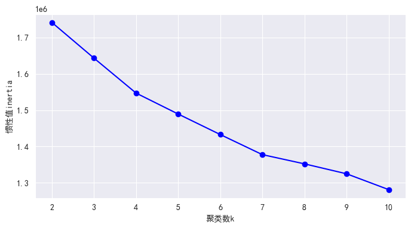

```python
##肘部法
inertia = []
K_range = range(2,11) ##测试2-10个簇
for k in K_range:
    kmeans = KMeans(n_clusters = k,random_state = 42,n_init = 10)
    kmeans.fit(process_data)
    inertia.append(kmeans.inertia_)

plt.rcParams['font.sans-serif'] = ['SimHei', 'Microsoft YaHei']  # 使用黑体或微软雅黑
plt.figure(figsize = (8,4))
plt.plot(K_range, inertia,'bo-')
plt.xlabel('聚类数k')
plt.ylabel('惯性值inertia')
plt.show()
```

肘部法最佳聚类数K=4

#### 执行K-Means聚类

```python
best_k = 4

kmeans = KMeans(n_clusters=best_k, random_state=42,n_init = 10)
df['Cluster'] = kmeans.fit_predict(process_data)
```

#### 聚类结果分析（提炼各簇特征）

```python
##数值型特征分析
num_analysis = df.groupby('Cluster')[num_features].mean().round(2)
print('===各簇数值型特征均值===')
display(num_analysis.style.set_table_attributes('style ="text-align:center;"'))

##类别型特征分析
def get_dominant_category(group,col):
    counts = group[col].value_counts(normalize = True)
    if len(counts) == 0:
        return(None,0)
    dominant = counts.index[0]
    ratio = counts.iloc[0].round(2)
    return(dominant,ratio)

##生成类别型特征主导标签
category_summary = []
for cluster in range(best_k):
    cluster_data = df[df['Cluster'] == cluster]
    row = {'Cluster':cluster,'用户占比':f"{len(cluster_data)/len(df):.2%}"}
    for col in cat_features:
        dominant, ratio = get_dominant_category(cluster_data,col)
        row[f'{col}_主导'] = f"{dominant}({ratio:.0%})"
    category_summary.append(row)

category_df = pd.DataFrame(category_summary)
print("\n===各簇类别型特征主导标签===")
display(category_df.style.set_table_attributes('style ="text-align:center;"'))
```

```
===各簇数值型特征均值===
```

| Cluster | 年龄 | 年收入 | 购买次数 | 网站停留时间 | 客户年限 | 上次购买天数 | 访问次数 | 客户满意度 | 购买状态 |
| --- | --- | --- | --- | --- | --- | --- | --- | --- | --- |
| 0 | 43.890000 | 85004.340000 | 11.390000 | 31.120000 | 2.220000 | 61.390000 | 2.350000 | 3.220000 | 0.410000 |
| 1 | 43.920000 | 85156.310000 | 11.390000 | 31.100000 | 2.210000 | 61.080000 | 2.350000 | 3.220000 | 0.420000 |
| 2 | 43.930000 | 85110.870000 | 11.400000 | 31.160000 | 2.220000 | 61.360000 | 2.360000 | 3.220000 | 0.420000 |
| 3 | 44.040000 | 85011.320000 | 11.410000 | 31.150000 | 2.210000 | 60.940000 | 2.350000 | 3.220000 | 0.420000 |

```
===各簇类别型特征主导标签===
```

|  | Cluster | 用户占比 | 性别_主导 | 产品类别_主导 | 偏好设备_主导 | 地区_主导 | 推荐来源_主导 | 客户细分_主导 |
| --- | --- | --- | --- | --- | --- | --- | --- | --- |
| 0 | 0 | 26.91% | Female(100%) | Fashion(22%) | Mobile(100%) | South(36%) | Organic(42%) | Premium(47%) |
| 1 | 1 | 27.51% | Male(100%) | Fashion(22%) | Mobile(100%) | South(36%) | Organic(41%) | Premium(48%) |
| 2 | 2 | 22.57% | Female(100%) | Fashion(22%) | Desktop(68%) | South(35%) | Organic(42%) | Premium(47%) |
| 3 | 3 | 23.00% | Male(100%) | Fashion(22%) | Desktop(69%) | South(36%) | Organic(42%) | Premium(48%) |

#### 可视化聚类结果

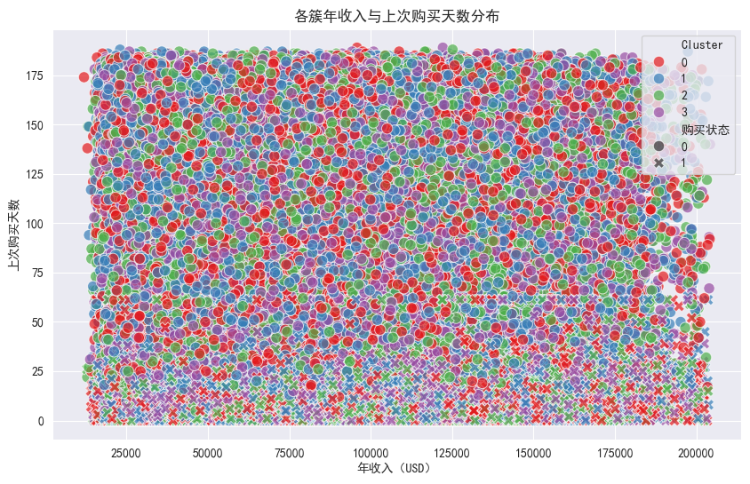

```python
plt.figure(figsize=(10,6))
sns.scatterplot(
    x='年收入',
    y='上次购买天数',
    hue='Cluster',
    style='购买状态',
    data=df ,
    palette='Set1',
    s=80,alpha=0.7
)
plt.rcParams['font.sans-serif'] = ['SimHei', 'Microsoft YaHei']  # 使用黑体或微软雅黑
plt.title('各簇年收入与上次购买天数分布')
plt.xlabel('年收入（USD）')
plt.ylabel('上次购买天数')
plt.show()
```

年收入与购买行为的关联

聚类（Cluster）的特征差异

运营策略建议

聚类间差异可作为用户分层运营的依据，例如对不同聚类设计差异化的营销触达（如高价值聚类推送新品，潜力聚类推送优惠券），实现精准运营。

#### 生成用户簇标签（画像总结）

```python
def summarize_cluster(cluster_id):
    num_stats = num_analysis.loc[cluster_id]
    cat_stats = category_df[category_df['Cluster'] == cluster_id].iloc[0]

    tags = [
        f"簇{cluster_id}({cat_stats['用户占比']})",
        f"年龄：{num_stats['购买次数']:.1f}次，满意度：{num_stats['客户满意度']:.1f}分",
        f"偏好：{cat_stats['产品类别_主导']}，设备：{cat_stats['偏好设备_主导']}",
        f"用户分层：{cat_stats['客户细分_主导']}"
    ]
    return '\n'.join(tags)

print("\n===各用户簇核心画像===")
for cluster in range(best_k):
    print(summarize_cluster(cluster))
    print("-" * 50)
```

[output not shown]

### 4、特征工程

#### 人口属性：年龄段×产品偏好×购买状态

[figure not shown]

0-18岁：用户规模极小，对各类产品品类（Furniture、Electronics 等）偏好均低，购买状态的用户数也极少，属于 “消费能力弱、市场占比低” 的群体。建议强化 Electronics、Fashion 品类的年轻化营销（如新品首发、社交电商玩法）。

19-30 岁：对 Electronics、Fashion 品类偏好显著，且购买状态 1（成功购买）的用户数随品类偏好同步增长，是 “时尚 + 科技品类的活跃消费群体”。建议强化 Electronics、Fashion 品类的年轻化营销（如新品首发、社交电商玩法），进一步提升转化效率。

31-45 岁、46-60 岁：Furniture、Kitchen、Fashion 品类偏好达到峰值，购买状态 1 的用户数也随之攀升，属于 “家庭场景消费（家居、厨房）+ 个人时尚消费” 的高转化群体。建议重点布局 Furniture、Kitchen 品类，推出家庭场景解决方案（如全屋定制、智能厨房套系）。

61 + 岁：Furniture 品类偏好仍较高，但 Kitchen、Fashion 品类偏好下降，购买状态 1 的用户数明显减少，消费更偏向 “居家刚需” 且转化意愿有所降低。建议优化 Furniture 品类的适老设计，简化购买流程，提升老年用户的消费体验与转化意愿。

#### 消费特征：客户分层×平均购买次数×购买状态

[figure not shown]

客户分层与购买次数的核心规律

VIP / Premium / Regular 客户分层与平均购买次数无明显相关性；“已购买” 群体的购买次数均高于 “未购买” 群体。

商业策略建议

针对 VIP 客户：提供专属权益（如定制化服务、会员专属折扣），进一步强化其消费粘性，维持高购买频次。

针对 Premium 客户：推出升级服务或高端产品套餐，引导其向 VIP 层级转化，提升整体消费频次。

针对 Regular 客户：通过个性化推荐、满减活动等方式刺激消费，提升其购买频次，同时筛选高潜力用户向Premium/VIP 层级培育。